# Homework 5 - INFSCI 2160: Data Mining

## 21 Nov 2017

### Meng Li (mel165@pitt.edu) | Hyunseok Choi (hyc23@pitt.edu) | Junchao Mei (jum68@pitt.edu)

## Task 1. (Text Mining): analyze the topical clusters from text data

```r
# load packages
library(plyr)
library(ggplot2)
library(tm)
library(lsa)
library(NMF)
```

```r
ng = read.csv("http://www.yurulin.com/class/spring2017_datamining/data/Newsgroup.csv",
                 header = TRUE,na.string=c('NA'),stringsAsFactors = FALSE)
```

```r
head(ng)
```

| Topic | Content |
| --- | --- |
| alt.atheism | amus atheist and agnost articl timmbak mcl timmbak mcl ucsb edu clam bake timmon write fallaci atheism faith hear faq beckon onc wonder rule delet you correct you didn conspiraci correct hard atheism … |
| alt.atheism | rushdi islam law jaeger buphi edu gregg jaeger write articl vice ico tek bobb vice ico tek robert beauchain write bennett neil bcci adapt koran rule bank time august gui write piec titl that impli cas… |
| alt.atheism | christian moral articl vice ico tek bobb vice ico tek robert beauchain write not believ god not concern disposit beneath provid evid requir evid that person thi god find compel fact god you you for mi… |
| alt.atheism | year can that christian moral articl rusnew manti mathew manti mathew write mccullou snake wisc edu mark mccullough write articl ursa bear halat pooh bear jim halat write atom not object aren even rea… |
| alt.atheism | amus atheist and agnost timmbak mcl ucsb edu bake timmon write li hypocrisi dude atheism take faith theism admit peopl take faith atheist faith kind faith that great invis pink unicorn not exist kind … |
| alt.atheism | southern baptist convent freemasonri southern baptist convent conven thi june charg that freemasonri incompat christian thought quot jame holli anti mason flag carrier amus you passag exact quot south… |

```r
dim(ng)
```

1. 7511

2. 2

```r
# check missing value again
# if False => do not have missing value
any(is.na(ng))
```

FALSE

### 1. Plot the histogram of number of documents per topic

```r
ng$Topic = as.factor(ng$Topic)
summary(ng$Topic)
```

**1**

1

**alt.atheism**

318

**comp.graphics**

389

**comp.os.ms-windows.misc**

394

**comp.sys.ibm.pc.hardware**

392

**comp.sys.mac.hardware**

385

**comp.windows.x**

392

**misc.forsale**

390

**rec.autos**

395

**rec.motorcycles**

398

**rec.sport.baseball**

397

**rec.sport.hockey**

397

**sci.crypt**

392

**sci.electronics**

389

**sci.med**

392

**sci.space**

394

**soc.religion.christian**

395

**talk.politics.guns**

364

**talk.politics.mideast**

376

**talk.politics.misc**

310

**talk.religion.misc**

251

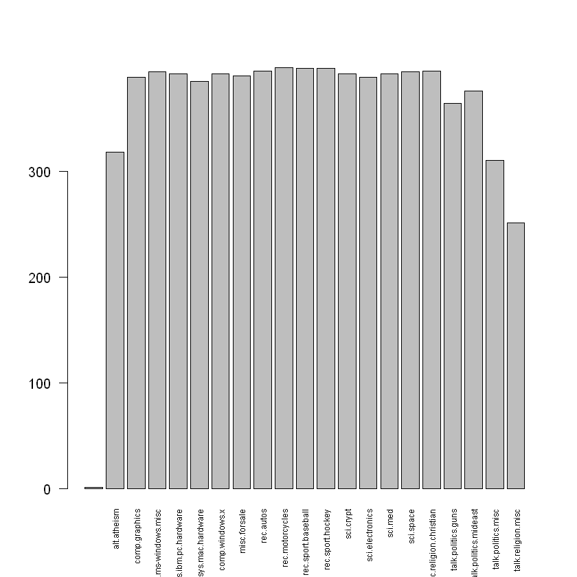

```r
barplot(table(ng$Topic),las=2,cex.names=0.6)
```

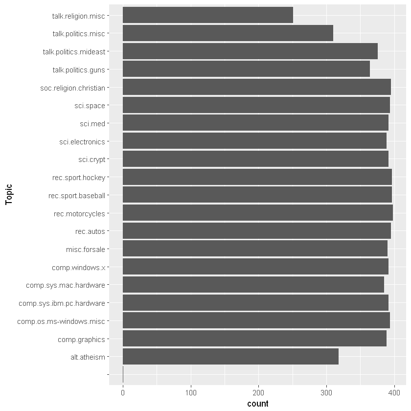

```r
# plot the same figure by following code looks more clear
ggplot(ng, aes(x=Topic)) + geom_bar() + coord_flip()
```

### 2. Extract contents in these top 4 topics as your corpus. Run pre-processing on this corpus and use terms that appear at least fourtimes in the corpus to create a term-document matrix. Use the term-document matrix to generate an MDS plot where each node represents a document with color indicating its topic.

```r
# find top 4 topics
select.topics = sort(table(ng$Topic), decreasing = T)[1:4]
select.topics = names(select.topics)
select.topics
doc.idx = which(ng$Topic %in% select.topics)
dataset = ng[doc.idx, ]
```

1. 'rec.motorcycles'

2. 'rec.sport.baseball'

3. 'rec.sport.hockey'

4. 'rec.autos'

```r
# select items with the top 4 topics
doc.idx = which(ng$Topic %in% select.topics)
dataset = ng[doc.idx, ]
# create a corpus
corpus = Corpus(VectorSource(dataset$Content))
corpus
```

```
<<SimpleCorpus>>
Metadata:  corpus specific: 1, document level (indexed): 0
Content:  documents: 1587
```

```r
## A corpus with 1587 text documents
# change all the text to lower case
corpus = tm_map(corpus, tolower)
inspect(corpus[1:3])  ## check if the texts are in lower case
```

```
<<SimpleCorpus>>
Metadata:  corpus specific: 1, document level (indexed): 0
Content:  documents: 3

[1] auto air condit freon articl hvx new cso uiuc edu tspila uxa cso uiuc edu tim spila romulan write articl apr ntuix ntu mgqlu ntuix ntu max write work ga solid adsorpt air con system for auto applic thi kind system energi for regener adsorb exhaust ga interest thi mail email follow thi thread dis…
[2] auto air condit freon rovax tobia convex allen tobia write year ago demonstr cold air system us air call rovax unit work short come seal technolog todai recal read post back rovax rovac di larger and noisier compet cheap system dai case bad time system chanc todai that system death row investor …
[3] auto air condit freon simpl principl porou adsorb zeolit and activ carbon can adsorb gase evapor adsorb water methanol etc give cool effect heat ga satur adsorb bed will give gase condens thi form adsorpt refriger cycl problem that cop low max max phd internet mgqlu ntu divis thermal engin bitne…
```

```r
# remove punctuations
corpus = tm_map(corpus, removePunctuation)
inspect(corpus[1:3])  ## check if punctuations are removed
```

```
<<SimpleCorpus>>
Metadata:  corpus specific: 1, document level (indexed): 0
Content:  documents: 3

[1] auto air condit freon articl hvx new cso uiuc edu tspila uxa cso uiuc edu tim spila romulan write articl apr ntuix ntu mgqlu ntuix ntu max write work ga solid adsorpt air con system for auto applic thi kind system energi for regener adsorb exhaust ga interest thi mail email follow thi thread dis…
[2] auto air condit freon rovax tobia convex allen tobia write year ago demonstr cold air system us air call rovax unit work short come seal technolog todai recal read post back rovax rovac di larger and noisier compet cheap system dai case bad time system chanc todai that system death row investor …
[3] auto air condit freon simpl principl porou adsorb zeolit and activ carbon can adsorb gase evapor adsorb water methanol etc give cool effect heat ga satur adsorb bed will give gase condens thi form adsorpt refriger cycl problem that cop low max max phd internet mgqlu ntu divis thermal engin bitne…
```

```r
# remove numbers
corpus = tm_map(corpus, removeNumbers)
inspect(corpus[1:3])  ## check if numbers are removed
```

```
<<SimpleCorpus>>
Metadata:  corpus specific: 1, document level (indexed): 0
Content:  documents: 3

[1] auto air condit freon articl hvx new cso uiuc edu tspila uxa cso uiuc edu tim spila romulan write articl apr ntuix ntu mgqlu ntuix ntu max write work ga solid adsorpt air con system for auto applic thi kind system energi for regener adsorb exhaust ga interest thi mail email follow thi thread dis…
[2] auto air condit freon rovax tobia convex allen tobia write year ago demonstr cold air system us air call rovax unit work short come seal technolog todai recal read post back rovax rovac di larger and noisier compet cheap system dai case bad time system chanc todai that system death row investor …
[3] auto air condit freon simpl principl porou adsorb zeolit and activ carbon can adsorb gase evapor adsorb water methanol etc give cool effect heat ga satur adsorb bed will give gase condens thi form adsorpt refriger cycl problem that cop low max max phd internet mgqlu ntu divis thermal engin bitne…
```

```r
# remove stopwords
corpus = tm_map(corpus, function(x) removeWords(x, stopwords("english")))
inspect(corpus[1:3])  ## check if stopwords are removed
```

```
<<SimpleCorpus>>
Metadata:  corpus specific: 1, document level (indexed): 0
Content:  documents: 3

[1] auto air condit freon articl hvx new cso uiuc edu tspila uxa cso uiuc edu tim spila romulan write articl apr ntuix ntu mgqlu ntuix ntu max write work ga solid adsorpt air con system  auto applic thi kind system energi  regener adsorb exhaust ga interest thi mail email follow thi thread discuss p…
[2] auto air condit freon rovax tobia convex allen tobia write year ago demonstr cold air system us air call rovax unit work short come seal technolog todai recal read post back rovax rovac di larger  noisier compet cheap system dai case bad time system chanc todai  system death row investor hard co…
[3] auto air condit freon simpl principl porou adsorb zeolit  activ carbon can adsorb gase evapor adsorb water methanol etc give cool effect heat ga satur adsorb bed will give gase condens thi form adsorpt refriger cycl problem  cop low max max phd internet mgqlu ntu divis thermal engin bitnet mgqlu…
```

```r
# stemming: such as changing "works" to "work"
corpus = tm_map(corpus, stemDocument, language = "english")
inspect(corpus[1:3])  ## check the stemming
```

```
<<SimpleCorpus>>
Metadata:  corpus specific: 1, document level (indexed): 0
Content:  documents: 3

[1] auto air condit freon articl hvx new cso uiuc edu tspila uxa cso uiuc edu tim spila romulan write articl apr ntuix ntu mgqlu ntuix ntu max write work ga solid adsorpt air con system auto applic thi kind system energi regen adsorb exhaust ga interest thi mail email follow thi thread discuss prosp…
[2] auto air condit freon rovax tobia convex allen tobia write year ago demonstr cold air system us air call rovax unit work short come seal technolog todai recal read post back rovax rovac di larger noisier compet cheap system dai case bad time system chanc todai system death row investor hard come…
[3] auto air condit freon simpl principl porou adsorb zeolit activ carbon can adsorb gase evapor adsorb water methanol etc give cool effect heat ga satur adsorb bed will give gase conden thi form adsorpt refrig cycl problem cop low max max phd internet mgqlu ntu divi thermal engin bitnet mgqlu ntuva…
```

```r
# strip whitespace
corpus = tm_map(corpus, stripWhitespace)
corpus  # check corpus
```

```
<<SimpleCorpus>>
Metadata:  corpus specific: 1, document level (indexed): 0
Content:  documents: 1587
```

```r
## A corpus with 1587 text documents
# run mds
td.mat = as.matrix(TermDocumentMatrix(corpus))
td = TermDocumentMatrix(corpus)
dim(td.mat)  ## dimension of term-doc matrix
```

1. 13547

2. 1587

```r
# find terms appear less than 4 times
allterm = findFreqTerms(td, 0)
freq4term = findFreqTerms(td, 4)
less4term = setdiff(allterm,freq4term)

summary(allterm)
summary(freq4term)
summary(less4term)
```

```
   Length     Class      Mode
    13547 character character
```

```
   Length     Class      Mode
     5313 character character
```

```
   Length     Class      Mode
     8234 character character
```

```r
group <- 10
n <- length(less4term)
r <- rep(1:ceiling(n/group),each=group)[1:n]
d <- split(less4term,r)

corpus.dense = corpus
for (i in 1:length(d)) {
  corpus.dense = tm_map(corpus.dense, function(x) removeWords(x, c(paste(d[[i]]))))
 }
```

```r
## A dense corpus with 1587 text documents
# run mds
td_dense.mat = as.matrix(TermDocumentMatrix(corpus.dense))
td_dense = TermDocumentMatrix(corpus.dense)
# chenck whether terms appear less than 4 times are removed
dim(td_dense)  ## dimension of term-doc matrix
```

1. 5313

2. 1587

```r
# inspect the term-document matrix we built
inspect(td_dense)
```

```
<<TermDocumentMatrix (terms: 5313, documents: 1587)>>
Non-/sparse entries: 95688/8336043
Sparsity           : 99%
Maximal term length: 17
Weighting          : term frequency (tf)
Sample             :
        Docs
Terms    1059 1138 1141 1374 1387 1389 1466 160 166 217
  articl    0    3    1    0    0    0    0   1   0   0
  can      10    8    3    0    0    1    4   1  13   2
  car       0    0    0    0    0    0    0  30  42  20
  don       0    5    3    0    0    0    0   1  10   0
  edu       0    4    3    0    0    1    0   4   1   0
  game      5    0    0    0    0   12    5   0   0   0
  thi      15   12    9    0    0    1    3  12  32  10
  will      1    8    1    0    0    0    0   1   0   6
  write     1    3    3    0    0    0    0   3   1   0
  year      0   11    1    0    0    0    1   1   1   0
```

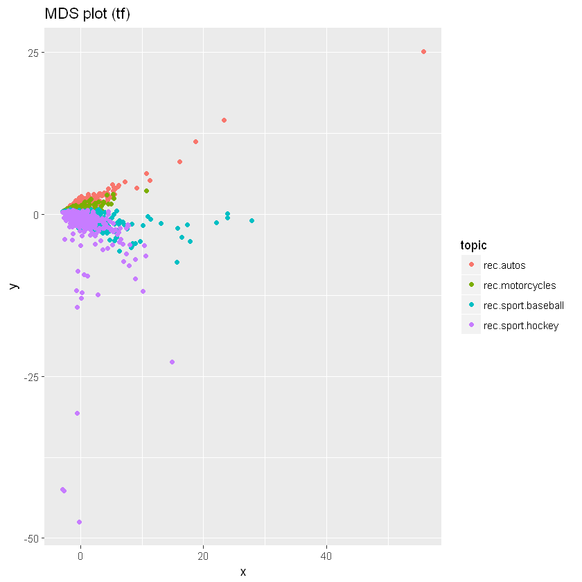

```r
dist.mat = dist(t(as.matrix(td_dense.mat)))  ## compute distance matrix

doc.mds = cmdscale(dist.mat, k = 2)
tf.data = data.frame(x = doc.mds[, 1], y = doc.mds[, 2], topic = dataset$Topic,
                  id = row.names(dataset))
tf.mdsplot = ggplot(tf.data, aes(x = x, y = y, color = topic)) + geom_point() + ggtitle("MDS plot (tf)")
tf.mdsplot
```

### 3. Apply TFIDF weithting, latent semantic analysis(LSA) and non-negative matrix factorization(NMF) on the term-document matrix. Generate MDS plots corresponding to these matrices.

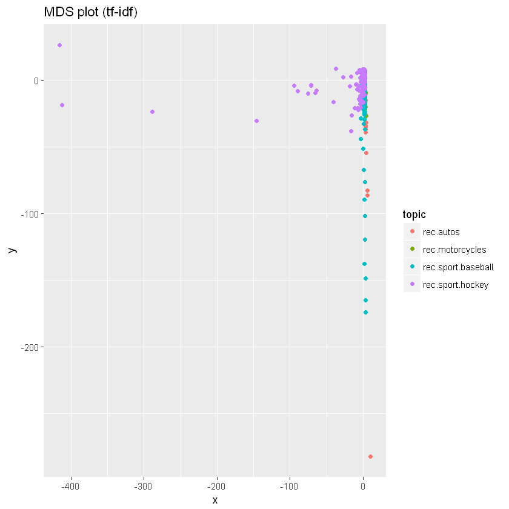

```r
######################################################################################################
####### use tf-idf weighting
td.mat.w = lw_tf(td_dense.mat) * gw_idf(td_dense.mat)  ## tf‐idf weighting
dist.mat = dist(t(as.matrix(td.mat.w)))
doc.mds = cmdscale(dist.mat, k = 2)
tfidf.data = data.frame(x = doc.mds[, 1], y = doc.mds[, 2], topic = dataset$Topic,
                  id = row.names(dataset))
tfidf.mdsplot = ggplot(tfidf.data, aes(x = x, y = y, color = topic)) + geom_point() + ggtitle("MDS plot (tf-idf)")
tfidf.mdsplot
```

```r
######################################################################################################
####### LSA
td.mat.w = lw_tf(td_dense.mat) * gw_idf(td_dense.mat)  ## tf‐idf weighting
lsa.space = lsa(td.mat.w, dims = 3) ## create LSA space
dist.mat = dist(t(as.textmatrix(lsa.space))) ## compute distance matrix
```

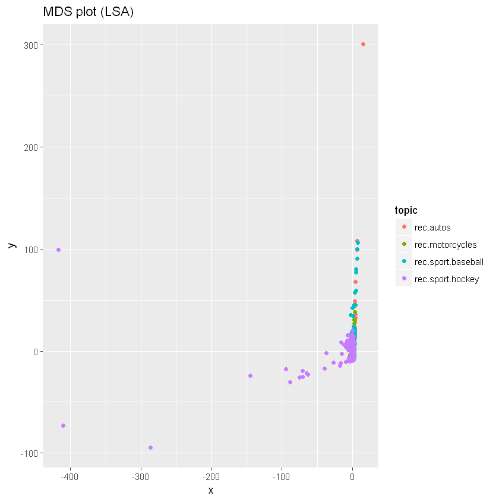

```r
doc.mds = cmdscale(dist.mat,k=2)
lsa.data = data.frame(x = doc.mds[,1], y = doc.mds[,2],topic = dataset$Topic,
                  id = row.names(dataset))
lsa.mdsplot = ggplot(lsa.data, aes(x = x, y = y, color = topic)) + geom_point() + ggtitle("MDS plot (LSA)")
lsa.mdsplot
```

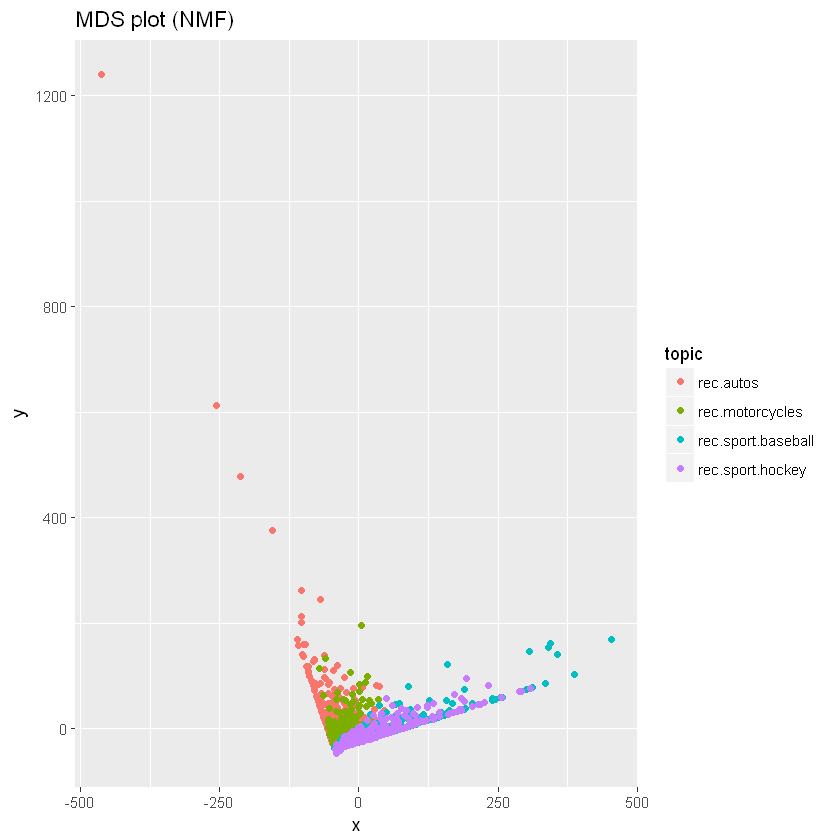

```r
######################################################################################################
####### NMF
set.seed(123)
res = nmf(td_dense.mat,3,'lee') # Lee & Seung method
# V.hat = fitted(res)
# w = basis(res) # term feature matrix
h = coef(res) # doc feature matrix

# mds
dist.mat = dist(t(as.textmatrix(h))) ## compute distance matrix
doc.mds = cmdscale(dist.mat,k=2)
nmf.data = data.frame(x = doc.mds[,1], y = doc.mds[,2],topic = dataset$Topic,
                  id = row.names(dataset))
nmf.mdsplot = ggplot(nmf.data, aes(x = x, y = y, color = topic)) + geom_point() + ggtitle("MDS plot (NMF)")
nmf.mdsplot
```

### 4 Write down your observation based on these plots

```r
####################################################################################
################################ Task 1.4 ##########################################
####################################################################################
### According to the MDS plots above, we can draw the following conclusions.
###
### Clustering with tf weighted matrix (default) does not perform well.
### The topic of 'rec.sport.baseball' is quite confusing.
###
### When we use tf-idf weighted matrix, it performs even worse.
### The points are compressed with many outliers.
###
### The NMF method performs better, but still cannot distinguish the topic of 'rec.sport.baseball' with others.
### Removing the non-negatice weights is the much better way to deal with such problem.
```

## Task 2. (Network Analysis): create a movie-movie network and identify the community structure and central nodes

### 1. Create a movie-to-movie co-rating network. Load u.data dataset, and extract data where the ratings are generated after timestamp 03/20/1998 00:00:00 and equal to rating 5. Extract the top 30 most frequently rated movies as the nodes. Generate a network with edge weights >= 10, i.e., two movies have a link if they are rated by at least 10 common users. Load u.item to replace movieID with movies titles. List the names of the top 10 movies and their number of ratings.

```r
library(igraph)
library(stats)
library(base)

data.path = "C:/Users/ptseo/Documents/JupyterNotebookWorkSpace/Pitt/DM_Fall2017/HW5/data/"
filename = sprintf("%s/%s", data.path, "u.data")
dataset = read.csv(filename, sep = "\t", header = F)
colnames(dataset) <- c("user_id", "item_id", "rating", "timestamp")
dim(dataset)
```

1. 100000

2. 4

```r
head(dataset)
```

| user_id | item_id | rating | timestamp |
| --- | --- | --- | --- |
| 196 | 242 | 3 | 881250949 |
| 186 | 302 | 3 | 891717742 |
| 22 | 377 | 1 | 878887116 |
| 244 | 51 | 2 | 880606923 |
| 166 | 346 | 1 | 886397596 |
| 298 | 474 | 4 | 884182806 |

```r
# extract data where the ratings are generated after timestamp 03/20/1998 00:00:00 and equal to rating 5

ts_19980320 = as.numeric(as.POSIXct("1998-03-20 00:00:00 EST")) # Unix timestamp for 03/20/1998 00:00:00
d1 = subset(dataset, (rating==5) & (timestamp > ts_19980320))

# extract the top 30 most frequently rated movies as the nodes.

movies = sort(table(d1$item_id), decreasing = T)
movies = rownames(movies[1:30])
movies
```

1. '50'

2. '313'

3. '272'

4. '100'

5. '318'

6. '127'

7. '302'

8. '316'

9. '174'

10. '603'

11. '56'

12. '357'

13. '483'

14. '98'

15. '172'

16. '168'

17. '12'

18. '22'

19. '258'

20. '496'

21. '89'

22. '181'

23. '315'

24. '427'

25. '515'

26. '269'

27. '1'

28. '132'

29. '173'

30. '185'

```r
# generate a network with edge weights >= 10

## create movie-movie co-rating network
df = subset(dataset, item_id %in% movies)
g = graph.data.frame(df, directed = T)
mat = get.adjacency(g)
mat = as.matrix(mat)
m2 = t(mat) %*% mat
movie.idx = which(colSums(m2) > 10)
movie.mat = m2[movie.idx, movie.idx]
diag(movie.mat) = 0 ## co-rating with self does not count
movie.idx = which(colSums(movie.mat) > 10)
movie.mat = movie.mat[movie.idx, movie.idx]
dim(movie.mat)
```

1. 30

2. 30

```r
movie.mat[1:3, ]
```

|  | 269 | 272 | 174 | 181 | 313 | 22 | 316 | 56 | 315 | 185 | ... | 427 | 98 | 173 | 132 | 496 | 483 | 515 | 603 | 127 | 50 |
| --- | --- | --- | --- | --- | --- | --- | --- | --- | --- | --- | --- | --- | --- | --- | --- | --- | --- | --- | --- | --- | --- |
| 269 | 0 | 115 | 121 | 143 | 159 | 91 | 80 | 114 | 100 | 82 | ... | 69 | 119 | 104 | 74 | 67 | 77 | 85 | 76 | 138 | 174 |
| 272 | 115 | 0 | 81 | 95 | 160 | 65 | 86 | 77 | 112 | 60 | ... | 46 | 84 | 65 | 56 | 48 | 57 | 46 | 45 | 81 | 110 |
| 174 | 121 | 81 | 0 | 342 | 146 | 258 | 52 | 314 | 63 | 193 | ... | 180 | 311 | 270 | 218 | 201 | 204 | 129 | 167 | 255 | 380 |

```r
uitem = read.csv("C:/Users/ptseo/Documents/JupyterNotebookWorkSpace/Pitt/DM_Fall2017/HW5/data/u.item", sep = "|", header = F)
colnames(uitem) <- c("movie_id", "movie_title", "release_date", "video_release_date",
              "IMDb_URL", "unknown", "Action", "Adventure", "Animation",
              "Children", "Comedy", "Crime", "Documentary", "Drama", "Fantasy",
              "Film-Noir", "Horror", "Musical", "Mystery", "Romance", "Sci-Fi",
              "Thriller", "War", "Western")
```

```r
top10movies = as.numeric(rownames(movie.mat)[order(colSums(movie.mat), decreasing=T)[1:10]])
top10movies
```

1. 50

2. 181

3. 174

4. 100

5. 98

6. 56

7. 172

8. 1

9. 127

10. 258

```r
# get movie ratings
number_of_ratings = colSums(movie.mat[, order(colSums(movie.mat), decreasing=T)[1:10]])
```

```r
# get movie title
top10 = uitem[top10movies, c("movie_id", "movie_title")]
```

```r
top10table = cbind(top10, number_of_ratings)
rownames(top10table) <- c(1:10)
top10table
```

| movie_id | movie_title | number_of_ratings |
| --- | --- | --- |
| 50 | Star Wars (1977) | 7273 |
| 181 | Return of the Jedi (1983) | 6525 |
| 174 | Raiders of the Lost Ark (1981) | 6306 |
| 100 | Fargo (1996) | 6170 |
| 98 | Silence of the Lambs, The (1991) | 5852 |
| 56 | Pulp Fiction (1994) | 5753 |
| 172 | Empire Strikes Back, The (1980) | 5675 |
| 1 | Toy Story (1995) | 5488 |
| 127 | Godfather, The (1972) | 5318 |
| 258 | Contact (1997) | 5214 |

```r
# put movie titles into the row and column names of the matrix
i = 1
column_names = as.numeric(colnames(movie.mat))
print(column_names)
for (movie_id in column_names){
    column_names[i] = as.character(uitem[movie_id, "movie_title"])
    i = i+1
}
colnames(movie.mat) <- column_names
rownames(movie.mat) <- column_names
```

```
 [1] 269 272 174 181 313  22 316  56 315 185 318   1 172 100  12  89 258 168 357
[20] 302 427  98 173 132 496 483 515 603 127  50
```

### 2. Identify the community structure in the network by using the modularity-based community detection algorithm. Plot the network with the detected community structure (use ’plot’) and the dendrogram (use ’dendPlot’).

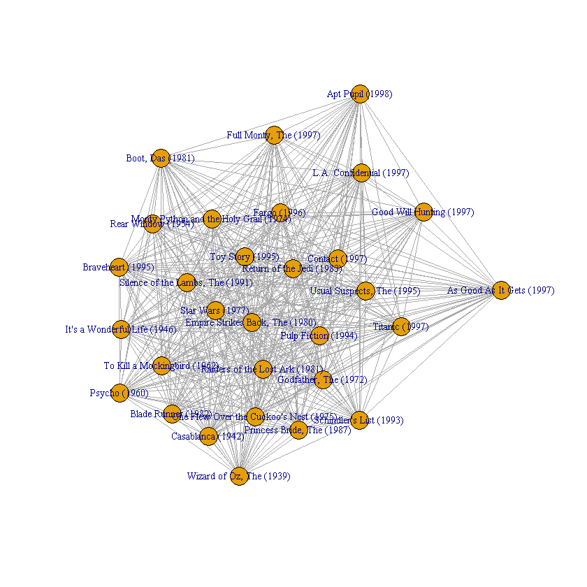

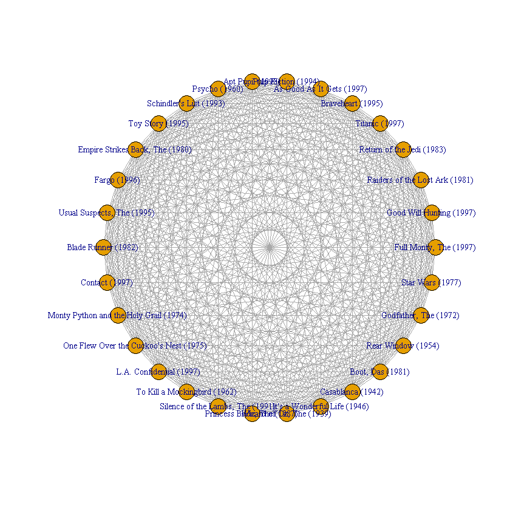

```r
g = graph.adjacency(movie.mat, weighted = T, mode = "undirected", diag = F)
set.seed(1)
plot(g, layout = layout.fruchterman.reingold, vertex.label = V(g)$name, vertex.size = 10, vertex.label.cex = 0.7)
plot(g, layout = layout.circle, vertex.label = V(g)$name, vertex.size = 10, vertex.label.cex = 0.7)
```

```r
# list top 30 movies
V(g)$name
```

1. 'Full Monty, The (1997)'

2. 'Good Will Hunting (1997)'

3. 'Raiders of the Lost Ark (1981)'

4. 'Return of the Jedi (1983)'

5. 'Titanic (1997)'

6. 'Braveheart (1995)'

7. 'As Good As It Gets (1997)'

8. 'Pulp Fiction (1994)'

9. 'Apt Pupil (1998)'

10. 'Psycho (1960)'

11. 'Schindler\'s List (1993)'

12. 'Toy Story (1995)'

13. 'Empire Strikes Back, The (1980)'

14. 'Fargo (1996)'

15. 'Usual Suspects, The (1995)'

16. 'Blade Runner (1982)'

17. 'Contact (1997)'

18. 'Monty Python and the Holy Grail (1974)'

19. 'One Flew Over the Cuckoo\'s Nest (1975)'

20. 'L.A. Confidential (1997)'

21. 'To Kill a Mockingbird (1962)'

22. 'Silence of the Lambs, The (1991)'

23. 'Princess Bride, The (1987)'

24. 'Wizard of Oz, The (1939)'

25. 'It\'s a Wonderful Life (1946)'

26. 'Casablanca (1942)'

27. 'Boot, Das (1981)'

28. 'Rear Window (1954)'

29. 'Godfather, The (1972)'

30. 'Star Wars (1977)'

```r
## get modularity-based community
fc = fastgreedy.community(g)
modularity(fc)
```

0.0323808933804296

```r
membership(fc)
```

```
                Full Monty, The (1997)               Good Will Hunting (1997)
                                     2                                      2
        Raiders of the Lost Ark (1981)              Return of the Jedi (1983)
                                     1                                      2
                        Titanic (1997)                      Braveheart (1995)
                                     2                                      1
             As Good As It Gets (1997)                    Pulp Fiction (1994)
                                     2                                      1
                      Apt Pupil (1998)                          Psycho (1960)
                                     2                                      1
               Schindler's List (1993)                       Toy Story (1995)
                                     1                                      2
       Empire Strikes Back, The (1980)                           Fargo (1996)
                                     1                                      2
            Usual Suspects, The (1995)                    Blade Runner (1982)
                                     1                                      1
                        Contact (1997) Monty Python and the Holy Grail (1974)
                                     2                                      1
One Flew Over the Cuckoo's Nest (1975)               L.A. Confidential (1997)
                                     1                                      2
          To Kill a Mockingbird (1962)       Silence of the Lambs, The (1991)
                                     1                                      1
            Princess Bride, The (1987)               Wizard of Oz, The (1939)
                                     1                                      1
          It's a Wonderful Life (1946)                      Casablanca (1942)
                                     1                                      1
                      Boot, Das (1981)                     Rear Window (1954)
                                     2                                      1
                 Godfather, The (1972)                       Star Wars (1977)
                                     2                                      2
```

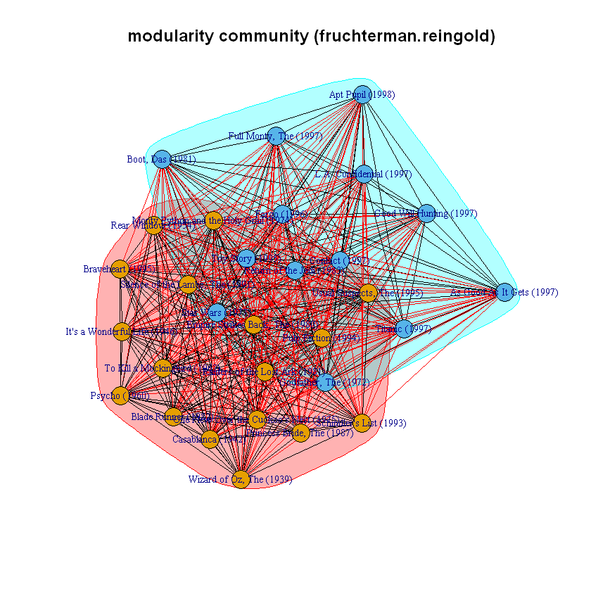

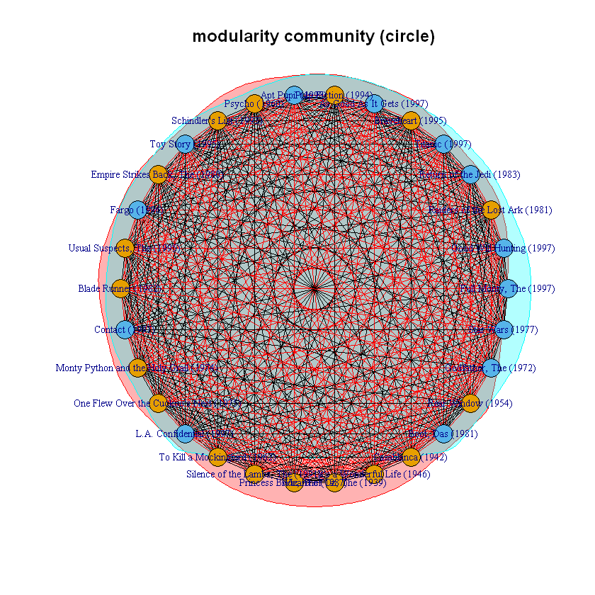

```r
set.seed(1)
plot(fc, g, main = "modularity community (fruchterman.reingold)", layout = layout.fruchterman.reingold, vertex.size = 10, vertex.label.cex = 0.7)
plot(fc, g, main = "modularity community (circle)", layout = layout.circle, vertex.size = 10, vertex.label.cex = 0.7)
```

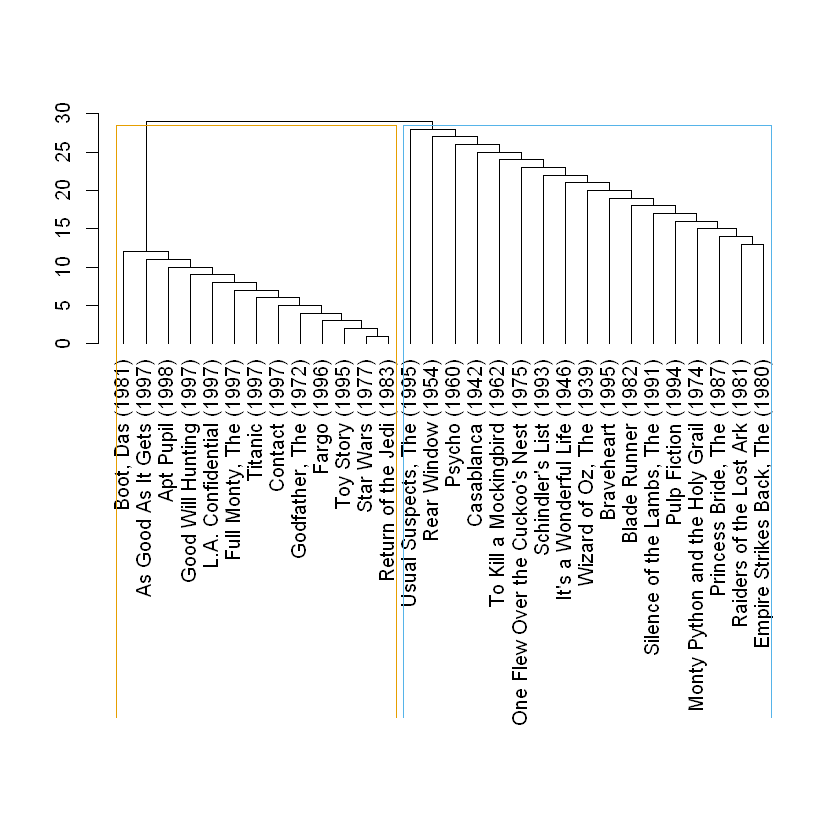

```r
dendPlot(fc)
```

### 3. Identify the most central nodes in the network based on different centrality measures, degree centrality, closeness centrality, betweenness centrality, and PageRank. Plot different networks where the nodes are sized based on the centrality measures. Highlight the top 5 nodes with the highest centrality measures in each network.

### Degree Centrality

```r
deg = degree(g)
deg
```

**Full Monty, The (1997)**

29

**Good Will Hunting (1997)**

29

**Raiders of the Lost Ark (1981)**

29

**Return of the Jedi (1983)**

29

**Titanic (1997)**

29

**Braveheart (1995)**

29

**As Good As It Gets (1997)**

29

**Pulp Fiction (1994)**

29

**Apt Pupil (1998)**

29

**Psycho (1960)**

29

**Schindler's List (1993)**

29

**Toy Story (1995)**

29

**Empire Strikes Back, The (1980)**

29

**Fargo (1996)**

29

**Usual Suspects, The (1995)**

29

**Blade Runner (1982)**

29

**Contact (1997)**

29

**Monty Python and the Holy Grail (1974)**

29

**One Flew Over the Cuckoo's Nest (1975)**

29

**L.A. Confidential (1997)**

29

**To Kill a Mockingbird (1962)**

29

**Silence of the Lambs, The (1991)**

29

**Princess Bride, The (1987)**

29

**Wizard of Oz, The (1939)**

29

**It's a Wonderful Life (1946)**

29

**Casablanca (1942)**

29

**Boot, Das (1981)**

29

**Rear Window (1954)**

29

**Godfather, The (1972)**

29

**Star Wars (1977)**

29

```r
top = order(deg, decreasing = T)[1:5]  ## the top-5 nodes with highest degrees
tiptop = order(deg, decreasing = T)[1]
top
```

1. 1

2. 2

3. 3

4. 4

5. 5

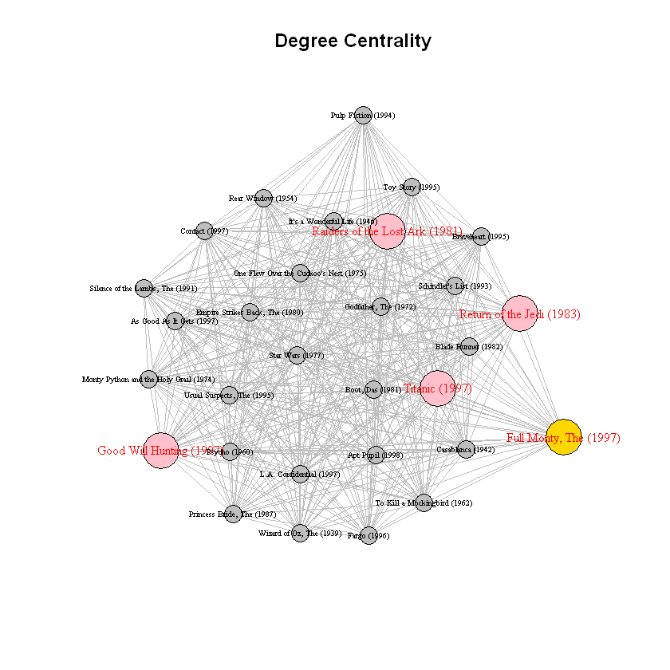

```r
## size node by degree
V(g)$size = abs(deg) * 0.3
V(g)$color = "gray"
V(g)$label.color = "black"
V(g)$label.cex = 0.5
E(g)$color = "gray"

#highlight the top-5 nodes
V(g)[top]$size = abs(deg) * 0.6
V(g)[top]$color = "pink"
V(g)[tiptop]$color = "gold"
V(g)[top]$label.color = "red"
V(g)[top]$label.cex = 0.8

set.seed(1)
plot(g, layout = layout.lgl)
title("Degree Centrality")
```

```r
measure = "Degree Centrality"
sprintf("The most central nodes identified in the network based on %s are", measure)
print(V(g)[top]$name)
```

'The most central nodes identified in the network based on Degree Centrality are'

```
[1] "Full Monty, The (1997)"         "Good Will Hunting (1997)"
[3] "Raiders of the Lost Ark (1981)" "Return of the Jedi (1983)"
[5] "Titanic (1997)"
```

### Closeness Centrality

```r
clo = closeness(g)
clo
```

**Full Monty, The (1997)**

0.000326583932070542

**Good Will Hunting (1997)**

0.000446627958910228

**Raiders of the Lost Ark (1981)**

0.000353232073472271

**Return of the Jedi (1983)**

0.00032123353678124

**Titanic (1997)**

0.000294811320754717

**Braveheart (1995)**

0.000398406374501992

**As Good As It Gets (1997)**

0.000668896321070234

**Pulp Fiction (1994)**

0.0003584229390681

**Apt Pupil (1998)**

0.000541711809317443

**Psycho (1960)**

0.000447427293064877

**Schindler's List (1993)**

0.000410172272354389

**Toy Story (1995)**

0.000371609067261241

**Empire Strikes Back, The (1980)**

0.000363108206245461

**Fargo (1996)**

0.000306842589751458

**Usual Suspects, The (1995)**

0.000415454923140839

**Blade Runner (1982)**

0.000413393964448119

**Contact (1997)**

0.000255036980362153

**Monty Python and the Holy Grail (1974)**

0.000402414486921529

**One Flew Over the Cuckoo's Nest (1975)**

0.000424448217317487

**L.A. Confidential (1997)**

0.000332446808510638

**To Kill a Mockingbird (1962)**

0.000487092060399416

**Silence of the Lambs, The (1991)**

0.000355239786856128

**Princess Bride, The (1987)**

0.000388802488335925

**Wizard of Oz, The (1939)**

0.0004516711833785

**It's a Wonderful Life (1946)**

0.000465116279069767

**Casablanca (1942)**

0.000437828371278459

**Boot, Das (1981)**

0.000480076812289966

**Rear Window (1954)**

0.000468384074941452

**Godfather, The (1972)**

0.000351617440225035

**Star Wars (1977)**

0.000305903946160905

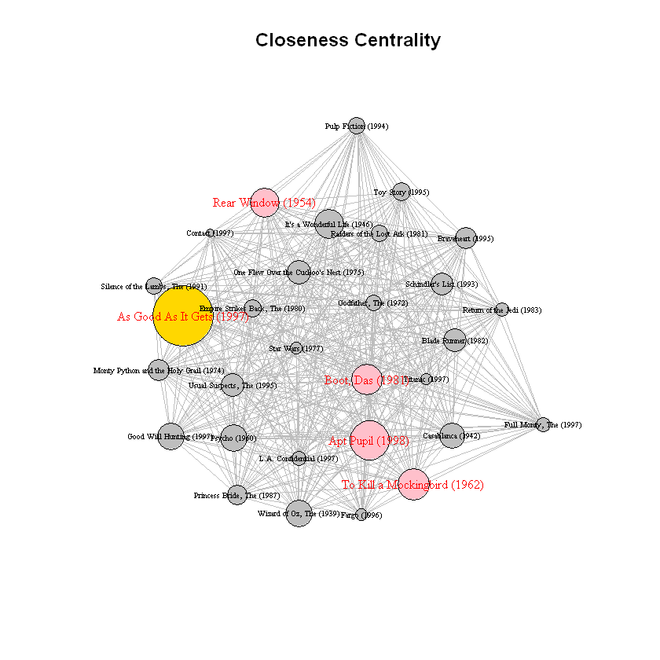

```r
top = order(clo, decreasing = T)[1:5]
tiptop = order(clo, decreasing = T)[1]

## size node by closeness
V(g)$size = abs(clo)^2 * 0.7e+08
V(g)$color = "gray"
V(g)$label.color = "black"
V(g)$label.cex = 0.5

# highlight the top-5 nodes
V(g)[top]$color = "pink"
V(g)[tiptop]$color = "gold"
V(g)[top]$label.color = "red"
V(g)[top]$label.cex = 0.8

set.seed(1)
plot(g, layout = layout.lgl)
title("Closeness Centrality")
```

```r
measure = "Closeness Centrality"
sprintf("The most central nodes identified in the network based on %s are", measure)
print(V(g)[top]$name)
```

'The most central nodes identified in the network based on Closeness Centrality are'

```
[1] "As Good As It Gets (1997)"    "Apt Pupil (1998)"
[3] "To Kill a Mockingbird (1962)" "Boot, Das (1981)"
[5] "Rear Window (1954)"
```

### Betweenness Centrality

```r
bet = betweenness(g)
bet
```

**Full Monty, The (1997)**

0

**Good Will Hunting (1997)**

0

**Raiders of the Lost Ark (1981)**

0

**Return of the Jedi (1983)**

0

**Titanic (1997)**

0

**Braveheart (1995)**

0

**As Good As It Gets (1997)**

286

**Pulp Fiction (1994)**

0

**Apt Pupil (1998)**

0

**Psycho (1960)**

0

**Schindler's List (1993)**

0

**Toy Story (1995)**

0

**Empire Strikes Back, The (1980)**

0

**Fargo (1996)**

0

**Usual Suspects, The (1995)**

0

**Blade Runner (1982)**

0

**Contact (1997)**

0

**Monty Python and the Holy Grail (1974)**

0

**One Flew Over the Cuckoo's Nest (1975)**

0

**L.A. Confidential (1997)**

0

**To Kill a Mockingbird (1962)**

4.83333333333333

**Silence of the Lambs, The (1991)**

0

**Princess Bride, The (1987)**

0

**Wizard of Oz, The (1939)**

0

**It's a Wonderful Life (1946)**

0.833333333333333

**Casablanca (1942)**

0

**Boot, Das (1981)**

3.5

**Rear Window (1954)**

3

**Godfather, The (1972)**

0

**Star Wars (1977)**

0

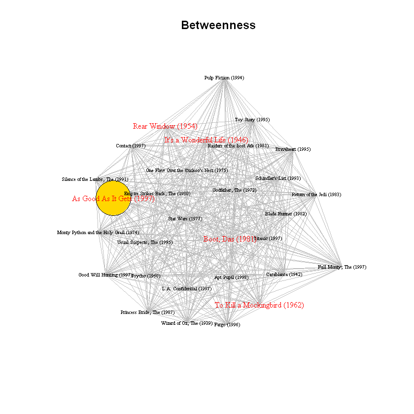

```r
top = order(bet, decreasing = T)[1:5]
tiptop = order(bet, decreasing = T)[1]

## size node by betweenness
V(g)$size = abs(bet) * 0.1
V(g)$color = "gray"
V(g)$label.color = "black"
V(g)$label.cex = 0.5

# highlight the top-5 nodes
V(g)[top]$color = "pink"
V(g)[tiptop]$color = "gold"
V(g)[top]$label.color = "red"
V(g)[top]$label.cex = 0.8

set.seed(1)
plot(g, layout = layout.lgl)
title("Betweenness")
```

```r
measure = "Betweenness Centrality"
sprintf("The most central nodes identified in the network based on %s are", measure)
print(V(g)[top]$name)
```

'The most central nodes identified in the network based on Betweenness Centrality are'

```
[1] "As Good As It Gets (1997)"    "To Kill a Mockingbird (1962)"
[3] "Boot, Das (1981)"             "Rear Window (1954)"
[5] "It's a Wonderful Life (1946)"
```

### PageRank

```r
pg = page.rank(g)$vector
pg
```

**Full Monty, The (1997)**

0.0258995881003069

**Good Will Hunting (1997)**

0.0202110986156336

**Raiders of the Lost Ark (1981)**

0.045203720859543

**Return of the Jedi (1983)**

0.046618826519841

**Titanic (1997)**

0.0287307114762574

**Braveheart (1995)**

0.0348670250716743

**As Good As It Gets (1997)**

0.0149617804747674

**Pulp Fiction (1994)**

0.0416751893561518

**Apt Pupil (1998)**

0.0176183589898853

**Psycho (1960)**

0.0294904987305384

**Schindler's List (1993)**

0.0341024772718799

**Toy Story (1995)**

0.0399493730263011

**Empire Strikes Back, The (1980)**

0.0411573539111214

**Fargo (1996)**

0.044450746522543

**Usual Suspects, The (1995)**

0.0320258981582362

**Blade Runner (1982)**

0.0338141983413017

**Contact (1997)**

0.0385872365938853

**Monty Python and the Holy Grail (1974)**

0.0364986319090827

**One Flew Over the Cuckoo's Nest (1975)**

0.0322219534411817

**L.A. Confidential (1997)**

0.0255623551849199

**To Kill a Mockingbird (1962)**

0.027132870895926

**Silence of the Lambs, The (1991)**

0.0423336018017659

**Princess Bride, The (1987)**

0.036427333382901

**Wizard of Oz, The (1939)**

0.0311124100613867

**It's a Wonderful Life (1946)**

0.0292439404621858

**Casablanca (1942)**

0.0302179218444413

**Boot, Das (1981)**

0.022994818448521

**Rear Window (1954)**

0.0264934418852932

**Godfather, The (1972)**

0.0389501529593502

**Star Wars (1977)**

0.0514464857031771

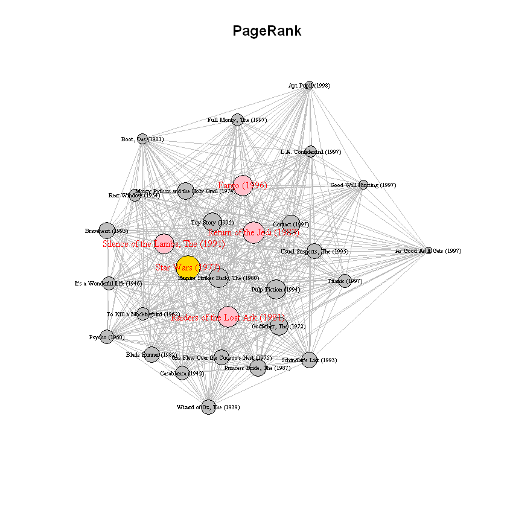

```r
top = order(pg,decreasing=T)[1:5]
tiptop = order(pg,decreasing=T)[1]

## size node by pagerank
V(g)$size = abs(pg) * 300
V(g)$color = "gray"
V(g)$label.color = "black"
V(g)$label.cex = 0.5

# highlight the top-5 nodes
V(g)[top]$color = "pink"
V(g)[tiptop]$color = "gold"
V(g)[top]$label.color = "red"
V(g)[top]$label.cex = 0.8

set.seed(1)
plot(g)
title("PageRank")
```

```r
measure = "PageRank"
sprintf("The most central nodes identified in the network based on %s are", measure)
print(V(g)[top]$name)
```

'The most central nodes identified in the network based on PageRank are'

```
[1] "Star Wars (1977)"                 "Return of the Jedi (1983)"
[3] "Raiders of the Lost Ark (1981)"   "Fargo (1996)"
[5] "Silence of the Lambs, The (1991)"
```

### 4. Write down your observation based on these plots.

> Centrality measures the importance of nodes in a network.

> (2) "As Good As It Gets (1997)", which has the highest Betweenness Centrality, can be though of a movie to bridge between different movie groups.

> (3) "As Good As It Gets (1997)" has also the most Closeness Centrality. That can be interpreted that it is closest to all the other movie nodes.

> (4) "Star Wars (1977)" has the highest PageRank. PageRank is a technique for estimating page quality. Considering the numbers of ratings of the movie nodes that direct to each movie, "Star Wars (1977)" is considered the most important movie.